# Insights into Life Expectancy across Income, Region, Population size, and Time

Kathleen DeBrota

# Applied Data Science Final Project

### Kathleen DeBrota, Spring 2019

## Introduction

It is well-known that human life expectancy has increased substantially in modern times, concurrent with advances in medicine, technology, and standards of hygiene. But how does one’s geographical location and income level determine how many of these modern benefits one can take advantage of? What patterns exist in life expectancy across the globe and across history, and how does a given country’s population size affect its individual inhabitants’ expected lifespan?

In this report, these questions are investigated with the help of an excerpt from the gapminder dataset (source: https://www.gapminder.org/data/).

## Data and library importation

```r
library(plyr)
library(dplyr)
library(tidyr)
library(corrplot)
library(lattice)
library(ggplot2)
library(purrr)
library(factoextra)
```

Import the data as a csv file:

```r
setwd('C:/Users/kdebr/OneDrive/Applied Data Science Class')
gapminder <- read.csv('C:/Users/kdebr/OneDrive/Applied Data Science Class/gapminder.csv')
```

## Description of Data, Data Cleaning, and Wrangling

The gapminder dataset contains life expectancy data between 1800 and 2015, juxtaposed with average demographic data such as income level and population size of the country in the given year. Countries are grouped into regions for easier geographical analysis.

```r
#Size of dataset
dim(gapminder)
```

```
## [1] 41284     6
```

```r
#Missing values check
sum(is.na(gapminder))
```

```
## [1] 28158
```

```r
#Datatypes
str(gapminder)
```

```
## 'data.frame':    41284 obs. of  6 variables:
##  $ country   : Factor w/ 197 levels "Ã…land","Afghanistan",..: 38 38 38 38 38 38 38 38 38 38 ...
##  $ year      : int  2015 2014 2013 2012 2011 2010 2009 2008 2007 2006 ...
##  $ life      : num  76.9 76.7 76.5 76.3 76.1 75.9 75.6 75.1 74.9 74.4 ...
##  $ population: int  1376048943 1369435670 1362514260 1355386952 1348174478 1340968737 1333807063 1326690636 1319625197 1312600877 ...
##  $ income    : int  13334 12609 11805 11017 10274 9430 8565 7880 7225 6360 ...
##  $ region    : Factor w/ 6 levels "America","East Asia & Pacific",..: 2 2 2 2 2 2 2 2 2 2 ...
```

```r
#Setting 'population' column to numeric instead of factor
gapminder$population<-as.numeric(gapminder$population)
```

The range of life expectancy values differs substantially based on the year in which the data was collected. A brief exploration of the range of this response variable:

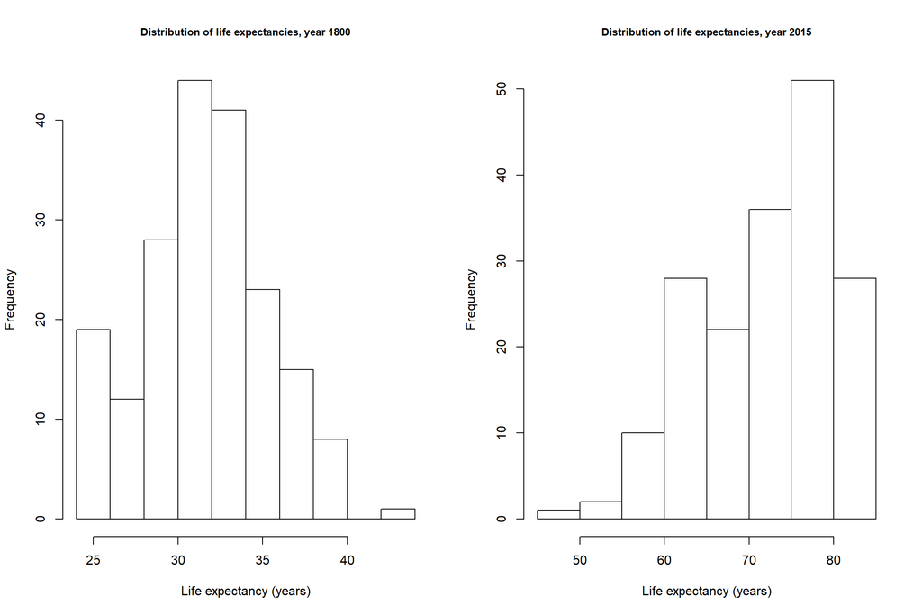

```r
par(mfrow=c(1,2))
#Histogram of 1800 life expectancy data
hist(gapminder$life[gapminder$year==1800], main='Distribution of life expectancies, year 1800', cex.main=0.8, xlab='Life expectancy (years)')


#Histogram of 2015 life expectancy data
hist(gapminder$life[gapminder$year==2015], main='Distribution of life expectancies, year 2015', cex.main=0.8, xlab='Life expectancy (years)')
```

```r
#Resetting the plotting parameters
par(mfrow=c(1,1))
```

From these histograms, it is abundantly clear that mean life expectancy has improved dramatically since 1800. The mean life expectancy for each year is shown below:

```r
life_1800_2015<-gapminder %>% group_by(year) %>% filter(year==c(1800, 2015)) %>% summarize(meanlife_exp=mean(life))
#supressed table output
```

The global life expectancy has more than doubled since 1800, from a mean of 31.3 years to 71.4.

### Basic stats

To further explore the ranges of all the variables in this dataset, a general statistical summary is presented:

```r
#Basic descriptive statistics
summary(gapminder)
```

```
##                 country           year           life
##  Afghanistan        :  216   Min.   :1800   Min.   : 1.00
##  Albania            :  216   1st Qu.:1854   1st Qu.:31.00
##  Algeria            :  216   Median :1908   Median :35.12
##  Angola             :  216   Mean   :1907   Mean   :42.88
##  Antigua and Barbuda:  216   3rd Qu.:1962   3rd Qu.:55.60
##  Argentina          :  216   Max.   :2015   Max.   :84.10
##  (Other)            :39988
##    population            income                              region
##  Min.   :1.548e+03   Min.   :   142   America                   : 7961
##  1st Qu.:5.335e+05   1st Qu.:   883   East Asia & Pacific       : 6256
##  Median :3.358e+06   Median :  1450   Europe & Central Asia     :10468
##  Mean   :2.119e+07   Mean   :  4571   Middle East & North Africa: 4309
##  3rd Qu.:1.078e+07   3rd Qu.:  3483   South Asia                : 1728
##  Max.   :1.376e+09   Max.   :182668   Sub-Saharan Africa        :10562
##  NA's   :25817       NA's   :2341
```

Life expectancy data ranges from 1 to 84.1 years, and population ranges from 1,548 to 1,376,000,000. Income ranges from $142/year to $182,668/year. The spread of this data is immense, and most likely represents an exponential increase in both income and population size.

### Data Preprocessing

Some variable creation and organization/arrangement of the data prior to further analysis.

```r
gapminder <- gapminder %>% group_by(country) %>% arrange(year, country)

#Selecting only the rows which contain a population value (every 10 years)
gapminderpop <- gapminder %>% filter(year%%10==0)

#Selecting only the numerical variables from the dataset for correlation plots.
numericonly <- sapply(gapminder, is.numeric)
numericonly <- na.omit(gapminder[,numericonly])
#sum(is.na(numericonly))
```

## Data Exploration

### **Research questions:**

1. Does average income determine average life expectancy?
2. How does average life expectancy change over time? Does it correlate with changes in average income?
3. Is life expectancy variable by region, and if so, which region has the highest/lowest life expectancy?
4. In which country was income the lowest yet life expectancy the highest? What might this tell us about the major factors driving life expectancy?
5. How does a larger population size influence life expectancy?
6. Can the data be clustered with respect to life expectancy, income, population, and year data? Which of these explains most of the variance in the data?

### **Question 1: Does average income determine average life expectancy?**

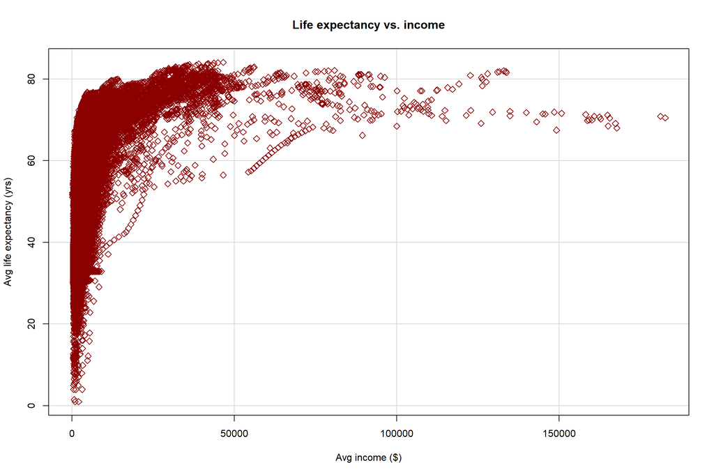

```r
#First, a quick visualization of the raw data of interest
plot(gapminder$income, gapminder$life, main='Life expectancy vs. income', xlab='Avg income ($)', ylab='Avg life expectancy (yrs)', col='darkred', pch=5,
grid(nx=NULL, ny=NULL, col='lightgray', lty=1))
```

There appears to be a nonlinear positive relationship between income and life expectancy, with an asymptote at the upper limits of human lifespan. Only those with the lowest average incomes have average life expectancies lower than about 40, and higher-average-income populations are almost never subject to a lower average lifespan (there are no outliers whose average income is >50,000 and whose life expectancy is <50 years).

To investigate the nature of the relationship between income and life expectancy, a linear regression was run on these variables. The resulting goodness-of-fit plots are shown below:

```r
#Linear regression of life expectancy vs. income data.
linreg <- lm(life~income, data=gapminder)
summary(linreg)
```

```
##
## Call:
## lm(formula = life ~ income, data = gapminder)
##
## Residuals:
##      Min       1Q   Median       3Q      Max
## -136.597   -8.726   -5.091   10.283   33.731
##
## Coefficients:
##              Estimate Std. Error t value Pr(>|t|)
## (Intercept) 3.873e+01  7.339e-02   527.7   <2e-16 ***
## income      9.217e-04  6.622e-06   139.2   <2e-16 ***
## ---
## Signif. codes:  0 '***' 0.001 '**' 0.01 '*' 0.05 '.' 0.1 ' ' 1
##
## Residual standard error: 13.19 on 38941 degrees of freedom
##   (2341 observations deleted due to missingness)
## Multiple R-squared:  0.3322, Adjusted R-squared:  0.3322
## F-statistic: 1.938e+04 on 1 and 38941 DF,  p-value: < 2.2e-16
```

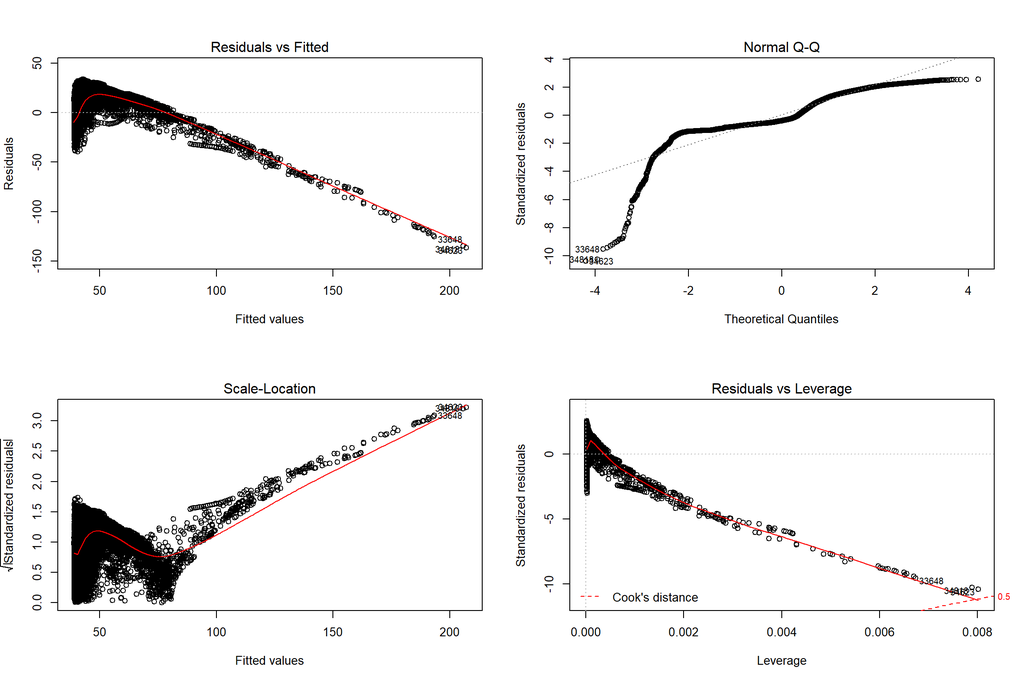

```r
par(mfrow=c(2,2))
plot(linreg)
```

The output of the linear regression shows that the relationship between income and life expectancy is certainly nonlinear, and it can be determined that the linear regression model is a poor fit to the data. From the Residuals vs. Fitted graph above, there is a clear pattern in the residuals, indicating a poor fit. The Normal Q-Q plot also shows strong deviation from the expected straight line, showing that the residuals are not normally distributed. The Scale-Location graph once again shows a strong pattern, indicating heteroscedasticity in the variances. Finally, the residuals vs. leverage graph shows that this data does not appear to have significant outliers.

Is the relationship exponential (life = income^n), since it was not a good fit for the previous linear model? If so, the linear regression of the log of each variable might show a good fit:

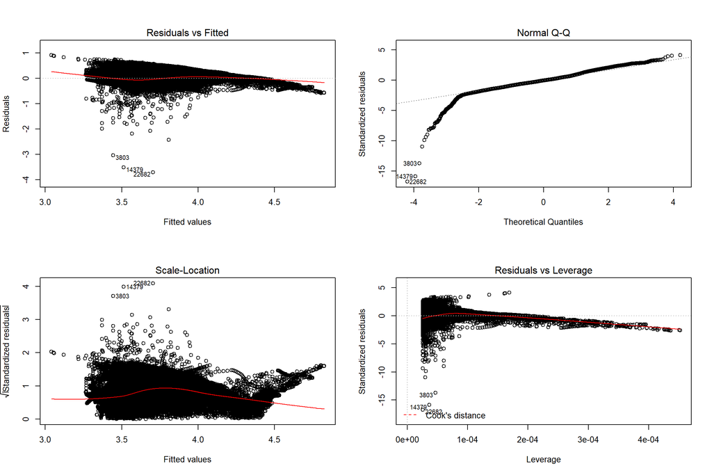

```r
par(mfrow=c(2,2))
expreg<- lm(log(life) ~ log(income), data=gapminder)
plot(expreg)
```

The above graphs once again show a poor fit, and the relationship is not exponential as hypothesized. The residuals are nonrandom (from Residuals vs. Fitted graph), and not normally distributed (Q-Q plot), and the data shows heteroscedasticity (Scale-Location graph). There may be influential outliers in this model (Residuals vs. Leverage), but this is largely irrelevant as the model will not be a good fit.

To determine the true nature of this nonlinear relationship, nonlinear regression could be carried out, but this is beyond the scope of this investigation.

However, we can clearly see the strong positive influence of income on life expectancy based on the raw data alone. It is important to remember, however, that the initial view of the raw data does not take time period or population size into account. Income may be a positive influence on life expectancy, but does not necessarily explain the entirety of the pattern we see in the data.

### **Question 2: How does average life expectancy change over time? Does it correlate to changes in income?**

We are interested in analyzing how life expectancy has changed in relation to how income has changed from 1800-2015.

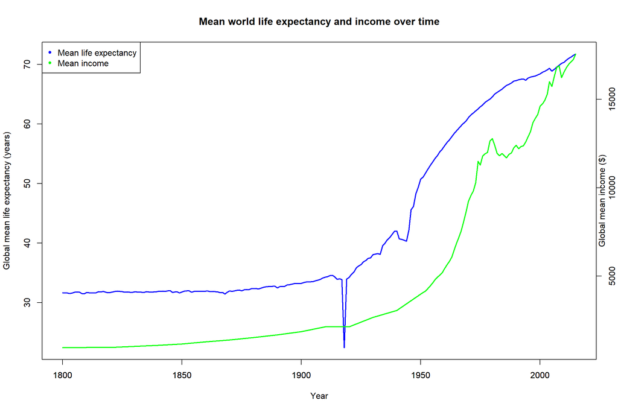

```r
#Find the mean life expectancy over all countries per year.
yearlymean<-gapminder %>% group_by(year) %>% summarize(meanlife=mean(life))

#plot the world yearly mean life expectancy.
plot(yearlymean$year, yearlymean$meanlife, col='blue',main='Mean world life expectancy and income over time', xlab='Year', ylab='Global mean life expectancy (years)', type='n')
lines(yearlymean$year, yearlymean$meanlife, col='blue', lty=1, lwd=2)

#Find global mean yearly income by year
gapminder<-na.omit(gapminder)
yearlymeanincome<-gapminder %>% group_by(year) %>% summarize(meanincome=mean(income))

#Plot this against the yearly average life expectancy from above
par(new=TRUE) #second y-axis
plot(yearlymeanincome$year, yearlymeanincome$meanincome, type='l', lwd=2, lty=1,ylab='', xlab='', col='green', pch=2, cex=0.8, yaxt='n', ann=FALSE)
axis(side=4)
mtext('Global mean income ($)', side=4)
legend('topleft', c('Mean life expectancy', 'Mean income'), col=c('blue', 'green'), pch=c(20, 20))
```

The visualization above shows the rise in both income and life expectancy globally over time. We can see that mean life expectancy and mean income are highly correlated, though not with the same slope (rate of increase is not the same for both variables). Around 1920, the global mean life expectancy began to rise dramatically, though income took a little longer to ‘catch up’ proportionally to this increase. Interestingly, there is a peak of income around 1975, followed by some stagnation and then further growth until 2015. The shape of the income curve is closer to exponential than the life expectancy curve, which appears to follow a classic sigmoidal shape - leveling off at a certain maximum ‘saturation point’ as humans have a maximum life span despite the possible influence of greater income. Meanwhile, there is no mandatory cap on the mean global income, so its growth is not limited in the same way. Income appears to have ‘taken off’ after about WW2 (~1950) and has continued to rise steeply since then.

This shows us that there is a strong correlation between income and expected lifespan. To visualize this in another way, we can run a correlation plot:

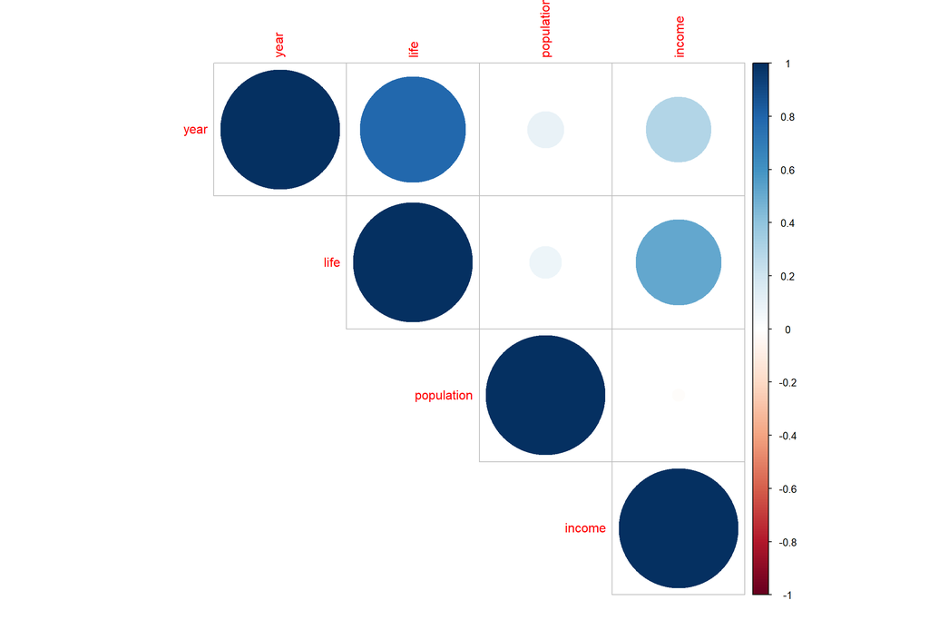

```r
#Correlation plot for all numeric variables
for_corr<-cor(numericonly)
corrplot(for_corr, method='circle', type='upper')
```

This plot shows us that there is a positive correlation between income and life expectancy, but also a stronger positive correlation between life expectancy and ‘year’, meaning that increasing income over time is only one part of the explanation for why the average lifespan has increased - other advancements in technology and medicine not captured in this dataset are responsible for much of the other increase in lifespan. Population size has a positive influence on lifespan, but a much smaller one.

### **Research question 3: Is life expectancy variable by region, and if so, which region has the highest/lowest life expectancy?**

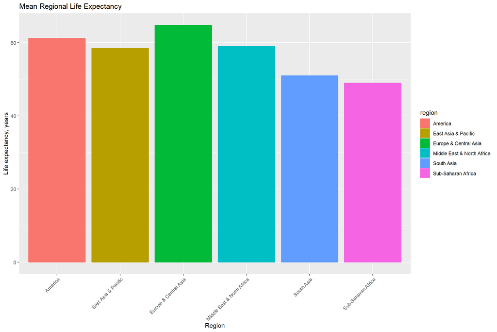

```r
#Group the data by region, then find regional mean life expectancy and regional mean income.

regionmeans <- gapminder %>% group_by(region) %>% summarize(life=mean(life), regionmeanincome=mean(income))%>% arrange(life)

regionmeans<-na.omit(regionmeans)

p<-ggplot(data=regionmeans, aes(x=region, y=life))
p+geom_bar(stat='identity', aes(color=region, fill=region)) +
theme(axis.text.x=element_text(angle=45, hjust=1)) +
  ylab("Life expectancy, years")+
  xlab("Region")+
  ggtitle("Mean Regional Life Expectancy")
```

From this quick analysis, it seems that Sub-Saharan Africa has the lowest regional life expectancy overall (throughout history), while Europe and Central Asia has the highest.

Diving deeper, we can visualize the spread of the data for each region using a boxplot:

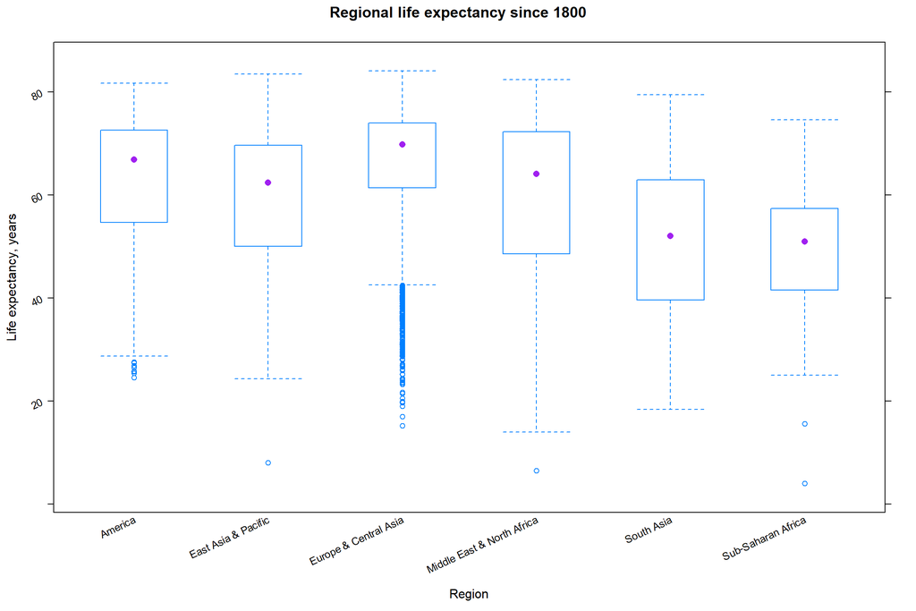

```r
regiongroups<-gapminder %>% group_by(region)
bwplot(regiongroups$life~regiongroups$region, scales=list(rot=25), col='purple', main='Regional life expectancy since 1800', ylab='Life expectancy, years', xlab='Region')
```

From the boxplot, it appears that the spread of data is largest for the Middle East and North Africa. This could possibly be explained by the existence of some countries which underwent serious challenges such as famine, natural disaster, or war, while other neighboring countries fared better or did not experience the same problems, or it could be the result of a particularly bad year or years across the entire region, such as a drought. This could be looked at as a metric of stability and regional self-sufficiency if that is the case, but such analysis would be outside the scope of this investigation.

Next, we would like to view the time-series plot of mean life expectancy by region. How have life expectancies changed over the course of history for each region, and did they change proportionally?

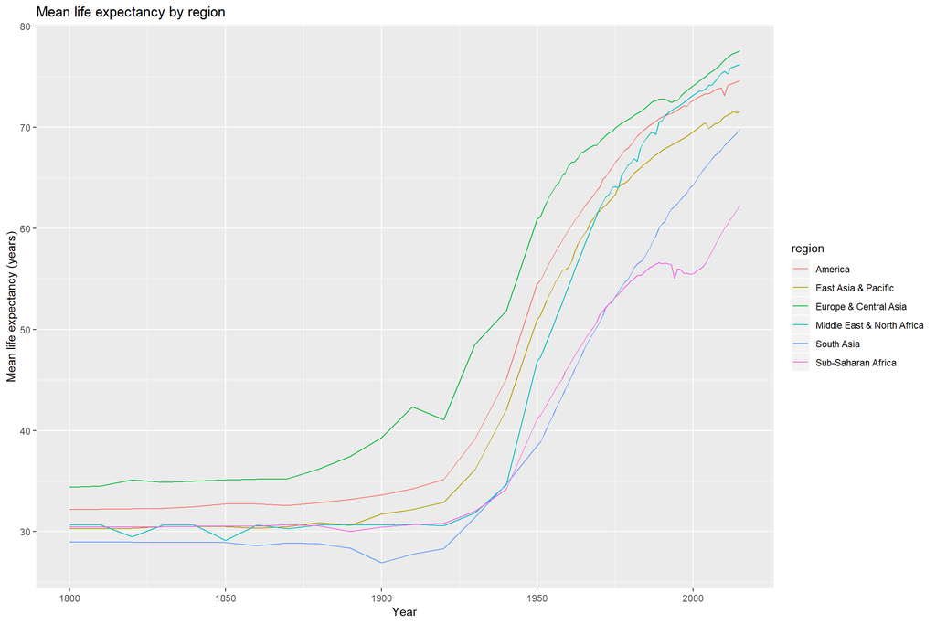

```r
#Generate yearly mean life expectancy data by region.
regionalmeans <- gapminder %>% group_by(region, year) %>% summarize(meanlife=mean(life))

#Plot regional means vs. time
ggplot(data=regionalmeans)+
  geom_line(mapping=aes(x=year, y=meanlife, color=region)) +
  xlab("Year")+
  ylab("Mean life expectancy (years)")+
  ggtitle("Mean life expectancy by region")
```

### **Research question 4: In which country was income the lowest yet life expectancy the highest?**

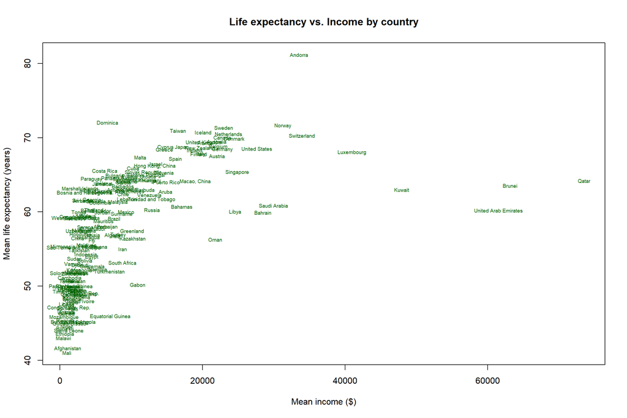

```r
#Generate mean income data by country, irrespective of year.
countrymeans <- gapminder %>% group_by(country) %>% summarize(meanincome=mean(income), meanlife=mean(life)) %>% arrange(desc(meanlife))

#Plot mean income by country by mean life expectancy.
plot(countrymeans$meanincome, countrymeans$meanlife, pch=20, col='white', xlab='Mean income ($)', ylab='Mean life expectancy (years)', main='Life expectancy vs. Income by country')
text(countrymeans$meanincome, countrymeans$meanlife, labels=countrymeans$country, cex=0.6, col='darkgreen')
```

Next, looking at a few specific years of data as a snapshot of history may tell us something about how lifespans have changed and for which countries.

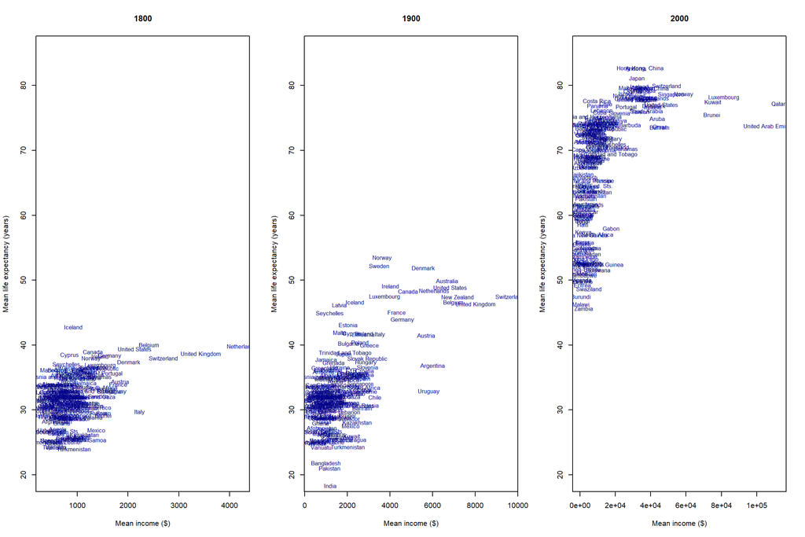

```r
#Now look at a few specific years of data.
means1800<- subset(gapminder, year==1800)
means1900<-subset(gapminder, year==1900)
means2000<-subset(gapminder, year==2000)

par(mfrow=c(1,3))

#Plot mean income by country by mean life expectancy for year 1800.
plot(means1800$income, means1800$life, pch=20, col='white', xlab='Mean income ($)', ylab='Mean life expectancy (years)', main='1800', cex.main=1.1, ylim=c(20, 85))
text(means1800$income, means1800$life, labels=means1800$country, cex=0.8, col='darkblue')

#Plot mean income by country by mean life expectancy for year 1900.
plot(means1900$income, means1900$life, pch=20, col='white', xlab='Mean income ($)', ylab='Mean life expectancy (years)', main='1900', cex.main=1.1, ylim=c(20, 85))
text(means1900$income, means1900$life, labels=means1900$country, cex=0.8, col='darkblue')

#Plot mean income by country by mean life expectancy for year 2000.
plot(means2000$income, means2000$life, pch=20, col='white', xlab='Mean income ($)', ylim=c(20,85), ylab='Mean life expectancy (years)', main='2000', cex.main=1.1)
text(means2000$income, means2000$life, labels=means2000$country, cex=0.8, col='darkblue')
```

Looking at a few specific dates (1800, 1900, and 2000), we can see how the bulk of the world’s countries did not advance much at all between 1800 and 1900 in terms of life expectancy or income. Only a few places whose incomes improved were also able to improve their mean life expectancy over that century. We can also see that in 1800 there was less income inequality globally, and that most people around the world had a similar approximate life expectancy - the spread was much lower in 1800 and even 1900 than it was in 2000. By the year 2000, some countries’ life expectancies were still under 50 years, while others were above 80 years. This could lead us to some important conclusions regarding the advancement of healthcare versus access to it in modern society.

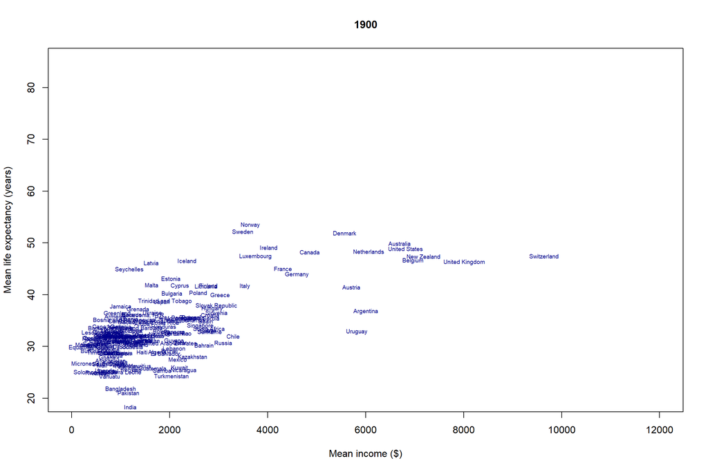

```r
par(mfrow=c(1,1))
#Compare 1900 and 2000.

#Plot mean income by country by mean life expectancy for year 1900.
plot(means1900$income, means1900$life, pch=20, col='white', xlab='Mean income ($)', ylab='Mean life expectancy (years)', main='1900', cex.main=1.1, ylim=c(20, 85), xlim=c(0,12000))
text(means1900$income, means1900$life, labels=means1900$country, cex=0.6, col='darkblue')
```

Taking a look at the graph for 1900 alone, we can identify some of the countries which were able to begin improving their life expectancy and income by this time: Switzerland, the UK, several other European and Scandinavian countries, Australia, and a few in South America such as Argentina and Uruguay are examples of this ‘early success’.

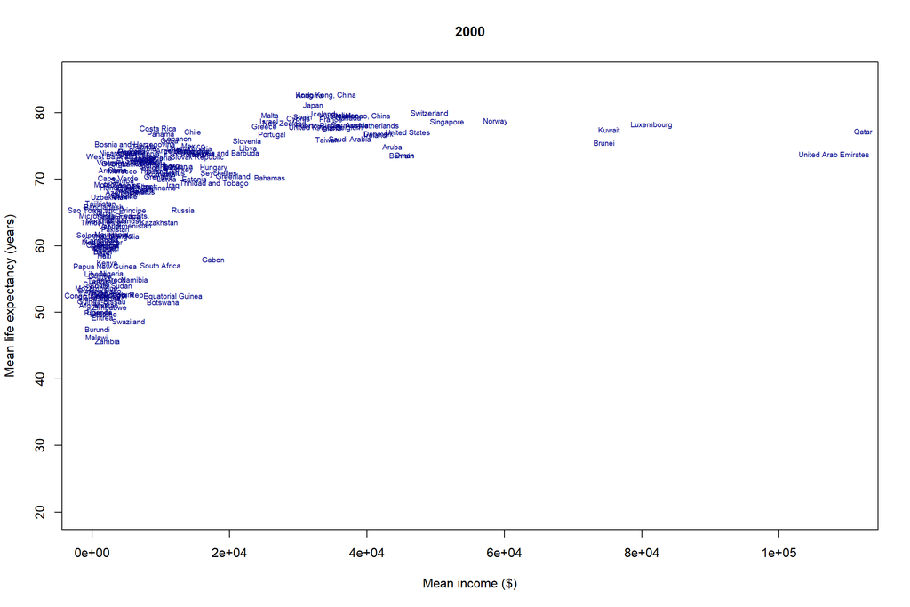

```r
#Plot mean income by country by mean life expectancy for year 2000.
plot(means2000$income, means2000$life, pch=20, col='white', xlab='Mean income ($)', ylim=c(20,85), xlim=c(0,110000), ylab='Mean life expectancy (years)', main='2000', cex.main=1.1)
text(means2000$income, means2000$life, labels=means2000$country, cex=0.6, col='darkblue')
```

### **Research question 5: How does a larger population size influence life expectancy?**

```r
gapminder$population <-as.numeric(gapminder$population)
countrymeanpop <- gapminder %>% group_by(country) %>% summarize(meanpop=mean(population), meanlife=mean(life)) %>% arrange(desc(meanpop))
#head(countrymeanpop)
```

This query shows us that the highest mean population size since 1800 occurred in China, with India, the United States, Indonseia, and Russia filling therest of the top 5. Plotting the mean population data by country against life expectancy will provide insight on how population impacts health:

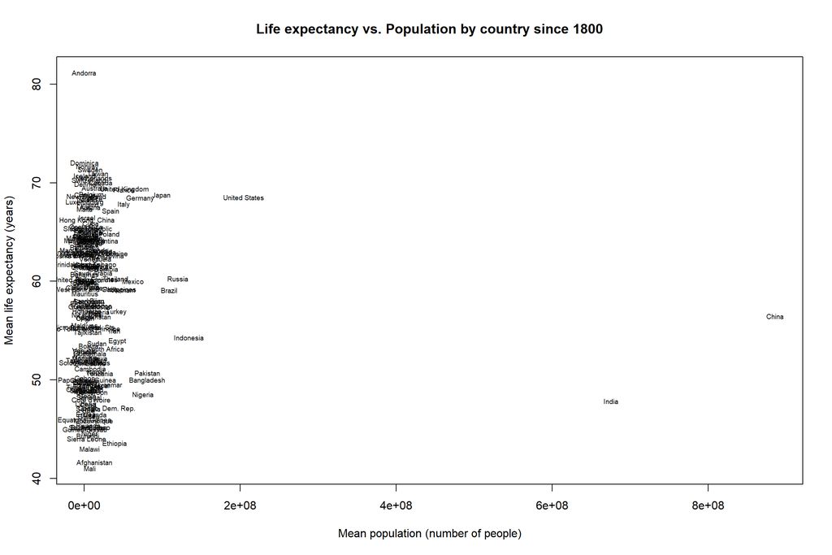

```r
plot(countrymeanpop$meanpop, countrymeans$meanlife, pch=20, col='white', xlab='Mean population (number of people)', ylab='Mean life expectancy (years)', main='Life expectancy vs. Population by country since 1800')
text(countrymeanpop$meanpop, countrymeanpop$meanlife, labels=countrymeanpop$country, cex=0.6)
```

This shows us that population does not correlate well with life expectancy: there are a few outliers with extremely high population sizes, but the rest of the data falls into a relatively random cluster with little to no pattern or variation visible across the population axis. Population is probably not a strong predictor of population size. ***

### **Research question 6: Can the data be clustered with respect to life expectancy, income, population, and year data? Which of these explains most of the variance in the data?**

To confirm the conclusions we have estimated based on the visualizations above, we can run k-means cluster analysis on the data.

[output not shown]

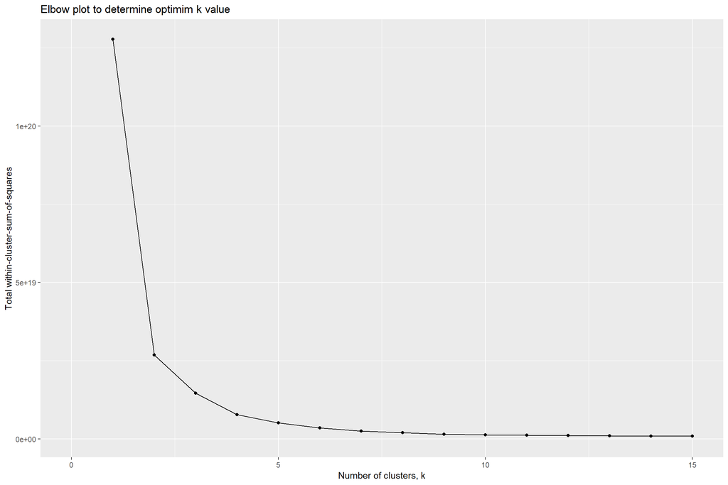

```r
#plot the elbow plot for the above analysis.
ggplot(elbow_df, aes(x=k, y=tot_withinss))+
  geom_point() +
  geom_line()+
  scale_x_continuous(breaks=1:200) +
  xlim(0,15) +
  ggtitle("Elbow plot to determine optimim k value")+
  xlab("Number of clusters, k")+
  ylab("Total within-cluster-sum-of-squares")
```

From the above within-sum-of-squares ‘elbow’ plot, we can see that the optimal number of clusters is 2.

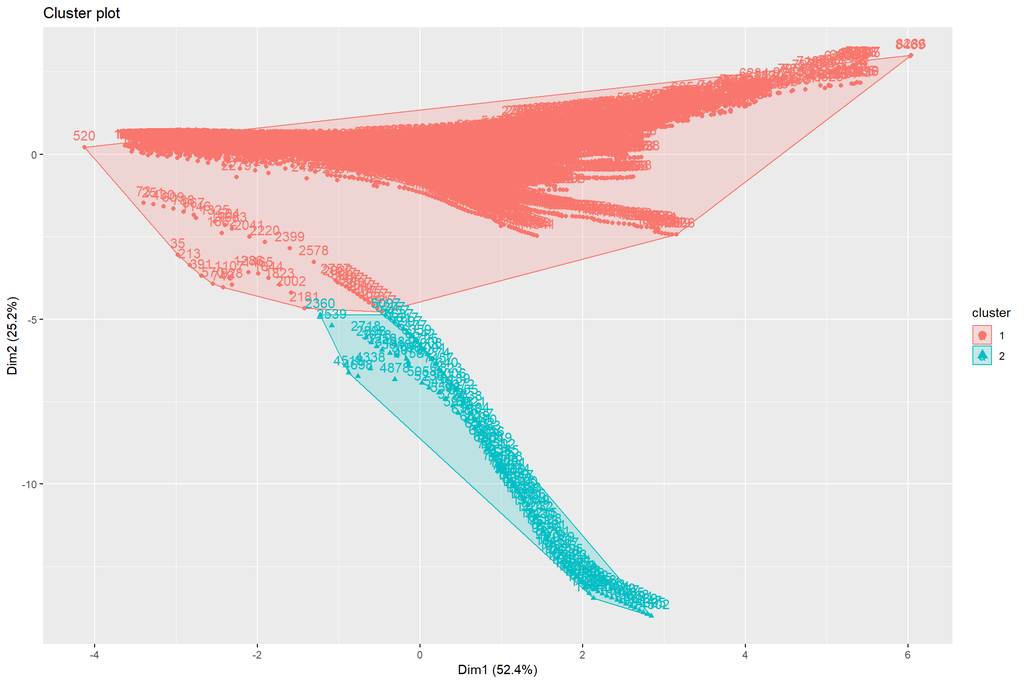

```r
#Running the cluster analysis with 2 clusters.
km <- kmeans(numeric, centers=2, iter.max=50)

#Visualizing the clusters.
fviz_cluster(km, numeric)
```

This cluster plot shows the clusters of datapoints laid out on two primary axes. Dimension 1 explains 52.4% of the variation in the dataset, while dimension 2 explains 25.2%. In total, these two principal components explain 77.6% of the variation in the data.

Performing a PCA (Principal Component Analysis) on the data shows the relative contribution of each principal component:

```r
PCA <- prcomp(numeric, center=TRUE, scale.=TRUE)
summary(PCA)
```

```
## Importance of components:
##                          PC1    PC2    PC3     PC4
## Standard deviation     1.448 1.0039 0.8455 0.42602
## Proportion of Variance 0.524 0.2520 0.1787 0.04537
## Cumulative Proportion  0.524 0.7759 0.9546 1.00000
```

The first two components explain most of the variation in the data set. A fuller explain the results of the clustering and PCA analysis is outside the scope of this report.

## Results and Discussion:

From analyzing the gapminder dataset, we have learned a lot about life expectancy throughout history, across countries and regions, and against varying population sizes and income levels. The major conclusions we can draw are that income does have a positive influence on life expectancy, but it is not the only contributing factor - many important variables such as rate of advancement of medicine and its availability to the majority of the population in a given country are not captured by the data set. However, we can say with some confidence that population size does not strongly impact the life expectancy of a given citizen of that country. Region is an important factor in life exspectancy, as certain regions consistently have higher or lower life expectancies than others, at least for the past two centuries.